# 203.2. The skyMap

For the Rubin Science Platform at data.lsst.cloud.  
Data Release: [Data Preview 2](https://dp2.lsst.io/)  
Container Size: large  
LSST Science Pipelines version: r30.0.11  
Last verified to run: 2026-09-15  
Repository: github.com/lsst/tutorial-notebooks  
DOI: 10.11578/rubin/dc.20250909.20

**Learning objective:** Understand how to access and use the skymap.

**LSST data products:** SkyMap.

**Packages:** `skyproj`, `lsst.daf.butler`, `lsst.geom`, `lsst.sphgeom`

**Credit:** Originally developed by the Rubin Community Science team. Please consider acknowledging them if this notebook is used for the preparation of journal articles, software releases, or other notebooks.

**Get Support:** Everyone is encouraged to ask questions or raise issues in the [Support Category](https://community.lsst.org/c/support) of the Rubin Community Forum. Rubin staff will respond to all questions posted there.

## 1. Introduction

This notebook demonstrates how to load and work with the `skyMap`. A given `skyMap` contains the definition of the tesselation of the sky into tracts, patches, and cells that are the fundamental blocks used for coaddition and object measurement. The `skyMap` object contains methods that can be used to find tracts, patches, and cells and their boundaries given an input coordinate.

**Related tutorials:** Information about tract/patch geometry can also be retrieved using the `CoaddPatches` table demonstrated in a 201-series tutorial. Detailed explorations of `Object` tables and `DeepCoadd` images are also in the 201 level. See also the 301-level overview notebooks for more details about the DP2 survey geometry.

### 1.1. Import packages

Import `numpy`, a fundamental package for scientific computing with arrays in Python (numpy.org), and `matplotlib`, a comprehensive library for data visualization ([matplotlib.org](https://matplotlib.org/); [matplotlib gallery](https://matplotlib.org/stable/gallery/index.html)). Import the `skyproj` package for plotting astronomical skymaps ([skyproj.readthedocs.io](https://skyproj.readthedocs.io/en/latest/)).

From the `lsst` package, import the `RSPDiscovery` class for accessing the RSP Table Access Protocol (TAP) service. Import the butler, `geom` and `sphgeom` packages, and plotting utilities from the LSST Science Pipelines (pipelines.lsst.io).

```python
import numpy as np
import matplotlib.pyplot as plt
import skyproj

from lsst.rsp import RSPDiscovery
from lsst.daf.butler import Butler
import lsst.geom as geom
import lsst.sphgeom as sphgeom
from lsst.utils.plotting import set_rubin_plotstyle
```

### 1.2. Define parameters and functions

Define parameters to use colorblind-friendly colors with `matplotlib`.

```python
set_rubin_plotstyle()
```

Instantiate the `butler`, and point it to the DP2 repo and collection.

```python
butler = Butler('dp2', collections=['dp2'])
```

Instantiate `RSPDiscovery` with the DP2 release, and create an instance of the TAP service.

```python
discovery = RSPDiscovery("dp2")
tap_service = discovery.get_tap_client()
```

Define the central coordinates of a field to use throughout. For later use, create an `lsst.geom.SpherePoint` object at that coordinate.

```python
ra = 290.0
dec = -20.8

coord = geom.SpherePoint(ra*geom.degrees, dec*geom.degrees)
```

## 2. Retrieve and examine the skyMap

The skymap defines the all-sky tesselation of tracts and patches for the deep coadd images.

Use the Butler's `get_dataset_type` function to show that the dimension for the `skyMap` dataset type is just `skymap`, and that the returned format for the skymap is `SkyMap`.

Show the schema for the `skyMap`.

```python
dataset_type = butler.get_dataset_type('skyMap')
print(f"dataset_type: {dataset_type}\n")
for dimension in dataset_type.dimensions.data_coordinate_keys:
    print('dimension = ', dimension)
    print(butler.dimensions[dimension].schema)
    print(' ')
```

```
dataset_type: DatasetType('skyMap', {skymap}, SkyMap)

dimension =  skymap
skymap:
  name: string
  hash: hash
    A hash of the skymap's parameters.
  tract_max: int
    Maximum ID for tracts in this skymap, exclusive.
  patch_nx_max: int
    Number of patches in the x direction in each tract.
  patch_ny_max: int
    Number of patches in the y direction in each tract.
```

The `skyMap` DatasetType requires specifying the skymap that was used to create it. See what keys are available for the skymap dimension using `query_dimension_records`.

```python
butler.query_dimension_records('skymap')
```

```
[skymap.RecordClass(name='lsst_cells_v2', hash=b'\xa5\xf1\x1eV\x15\x05\xdck$\xec\x8fN\xf5G\xbcY.\x82\x99\xda', tract_max=18938, patch_nx_max=10, patch_ny_max=10)]
```

There is only the `lsst_cells_v2` skymap for DP2.

Retrieve the `skyMap` from the butler, specifying `lsst_cells_v2` in the `skymap` argument.

```python
skymap = butler.get('skyMap', skymap='lsst_cells_v2')
```

Uncomment all lines in the following cell to see all methods associated with the returned `skyMap`.

```python
# for tmp in dir(skymap):
#     if tmp[0] != '_':
#         print(tmp)
```

### 2.1. Tracts and patches via coordinates

#### 2.1.1. Nearest tract/patch to coordinate

Find the tract and patch whose center is nearest to the coordinate specified in Section 1. This method expects the input to be a list of `SpherePoint` objects (note that the list can contain multiple entries, in which case it will return the closest tract/patch for each item in the list).

```python
closest_tract_patch = skymap.findClosestTractPatchList([coord])
closest_tract_patch
```

```
[(TractInfo(id=6324, ctrCoord=[0.30976315626767525, -0.8866455017580095, -0.34337521930298853]),
  (PatchInfo(index=Index2D(x=0, y=0), innerBBox=(minimum=(0, 0), maximum=(2999, 2999)), outerBBox=(minimum=(-150, -150), maximum=(3149, 3149)), cellInnerDimensions=(150, 150), cellBorder=0, numCellsPerPatchInner=22),))]
```

This method returns the xy *indices* of the patch. Extract the `PatchInfo` object from the list that is returned, and use the `getSequentialIndex` to get the patch number.

```python
patchinfo = closest_tract_patch[0][1][0]
print(f"patch ID: {patchinfo.getSequentialIndex()}")
```

```
patch ID: 0
```

Find the tract/patch overlapping a coordinate with a different method. This time, use `skyMap.findTract`, then `findPatch` from the results of the tract query; this will return only the tract and patch IDs.

```python
my_tract = skymap.findTract(coord)
my_patch = my_tract.findPatch(coord)
print(my_tract.tract_id, my_patch.getSequentialIndex())
```

```
6324 0
```

#### 2.1.2. All tracts overlapping coordinate

Find all tracts overlapping the coordinate specified in Section 1. This method expects the input to be a `SpherePoint` object.

```python
alltracts = skymap.findAllTracts(coord)
alltracts
```

```
[TractInfo(id=6096, ctrCoord=[0.3214247684691223, -0.8726543995830115, -0.36764169663272]),
 TractInfo(id=6324, ctrCoord=[0.30976315626767525, -0.8866455017580095, -0.34337521930298853]),
 TractInfo(id=6325, ctrCoord=[0.3339708415166301, -0.8778137249925514, -0.34337521930298853])]
```

Note that the result from `findClosestTractPatchList` is one of the results from `findAllTracts`, but that "alltracts" contains multiple entries. This is because tracts and patches overlap at their edges.

#### 2.1.3. Tracts containing a list of coordinates

Create arrays of RA, Dec coordinates and search for tracts containing those coordinates using `findTractIdArray`. Specify `degrees=True` to tell the method that the input coordinates are in degrees (if not specified, they are assumed to be in radians).

```python
ra_array = np.array([ra, ra+5.0, ra+12.0])
dec_array = np.array([dec, dec+2.0, dec+4.0])

tract_ids = skymap.findTractIdArray(ra_array, dec_array, degrees=True)

print(tract_ids)
```

```
[6324 6558 6795]
```

The `findTractIdArray` returns a single result for each input coordinate. If the coordinate lies in a region of overlap between tracts, the id of the nearest tract will be returned.

#### 2.1.4. Tracts/patches within a region

Create a rectangular region based on four corner coordinates. Convert these to a list of `SpherePoint` objects, then find the tract/patch info for all patches overlapping the region.

```python
width = 0.5*geom.degrees

coords = []
coeffs = [(0.5, 0.5), (0.5, -0.5), (-0.5, -0.5), (-0.5, 0.5)]
for coeff_ra, coeff_dec in coeffs:
    coords.append(geom.SpherePoint(ra*geom.degrees+(width*coeff_ra),
                                   dec*geom.degrees+(width*coeff_dec)))

print(coords)

tractpatch_in_region = skymap.findTractPatchList(coords)
```

```
[SpherePoint(290.25*degrees, -20.55*degrees), SpherePoint(290.25*degrees, -21.05*degrees), SpherePoint(289.75000000000006*degrees, -21.05*degrees), SpherePoint(289.75000000000006*degrees, -20.55*degrees)]
```

```python
for i in range(len(tractpatch_in_region)):
    npatches = len(tractpatch_in_region[i][1])
    print(f"{npatches} patches in tract {tractpatch_in_region[i][0].getId()}.")
```

```
6 patches in tract 6325.
8 patches in tract 6096.
9 patches in tract 6324.
```

The region encompasses a total of 23 patches distributed across 3 tracts.

#### 2.1.5. RA, Dec range of tract

Print the min/max RA, Dec of tract 6325.

```python
skymap.getRaDecRange(6325)
```

```
(Angle(290.04366812227079, degrees),
 Angle(291.61572052401743, degrees),
 Angle(-20.826446280991735, degrees),
 Angle(-19.338842975206607, degrees))
```

Print the vertices (corners) of the tract. These will appear as `SpherePoint` objects that contain RA, Dec pairs.

```python
my_tract = skymap.generateTract(6325)
my_tract.vertex_list
```

```
[SpherePoint(291.72161721625366*degrees, -20.91357632950237*degrees),
 SpherePoint(289.93771197612944*degrees, -20.913576020859665*degrees),
 SpherePoint(289.9471465352892*degrees, -19.247226759672763*degrees),
 SpherePoint(291.71218328574196*degrees, -19.247227041683743*degrees)]
```

## 3. Plotting tract/patch boundaries

### 3.1. Plot all DP2 tracts

Query the `CoaddPatches` table from the TAP service to retrieve information about all DP2 tracts and patches. Then extract a list of unique tracts.

```python
query = """SELECT lsst_patch, lsst_tract, s_dec, s_ra, s_region FROM dp2.CoaddPatches"""
job = tap_service.submit_job(query)
job.run()
job.wait(phases=['COMPLETED', 'ERROR'])
print('Job phase is', job.phase)
if job.phase == 'ERROR':
    job.raise_if_error()
assert job.phase == 'COMPLETED'
patches_table = job.fetch_result().to_table()
job.delete()
del query
```

```
Job phase is COMPLETED
```

```python
tracts = np.unique(patches_table['lsst_tract'])
print('Number of tracts: ', len(tracts))
```

```
Number of tracts:  2191
```

Plot the boundaries of all DP2 tracts on a map of the sky using the `skyproj` package. Generate the tract coordinates using the `skyMap.generateTract` method, then extract the vertices and convert them to RA, Dec coordinates.

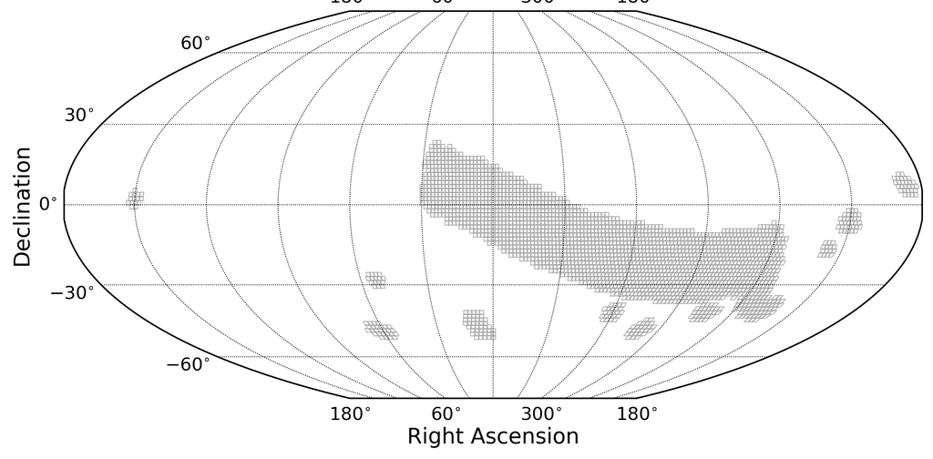

```python
fig, ax = plt.subplots(figsize=(10, 6))
sp = skyproj.McBrydeSkyproj(ax=ax)
for tract in tracts:
    info = skymap.generateTract(tract)
    vert_list = info.getVertexList()
    ras, decs = zip(*[[vert.getRa().asDegrees(), vert.getDec().asDegrees()] for vert in vert_list])
    sp.draw_polygon(ras, decs, edgecolor='darkgrey', alpha=1, linewidth=0.5, facecolor=None)
sp.ax.set_xlabel("Right Ascension", fontsize=14)
sp.ax.set_ylabel("Declination", fontsize=14)
plt.show()
```

> **Figure 1:** All-sky spatial plot (in equatorial RA, Dec coordinates) showing the 2191 tracts with data in DP2 as small gray squares.

### 3.2. Plot patches in a small sky area

Query the butler for all *r*-band `deep_coadd` images within a 1.5 degree radius of a given position. Extract the tract and patch IDs for these from the returned DatasetRefs.

```python
radius = 1.5
region = sphgeom.Region.from_ivoa_pos(f"CIRCLE {ra} {dec} {radius}")
query = "patch.region OVERLAPS :region AND band=:band"
bind_params = {'region': region, 'band': 'r'}
coadd_refs = butler.query_datasets("deep_coadd",
                                   where=query,
                                   bind=bind_params)

tractpatch_list = [(ref.dataId['tract'], ref.dataId['patch']) for ref in coadd_refs]
```

Use `generateTract`, `getPatchInfo`, and the WCS to extract the corner coordinates of each patch in RA, Dec. Assign each unique tract its own color, and label the patches.

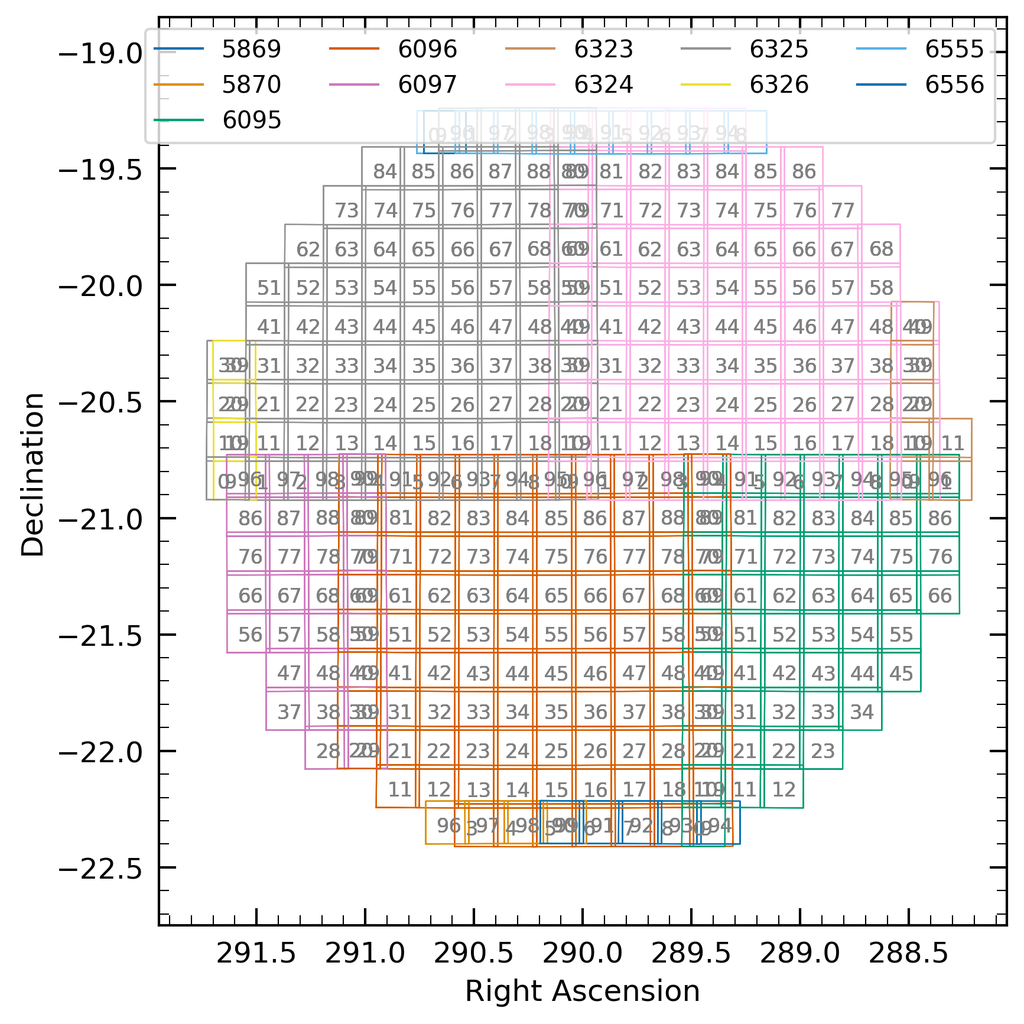

```python
tracts_selected = np.unique([tract for tract, patch in tractpatch_list])
tract_colors = {}
for i in range(len(tracts_selected)):
    tract_colors[tracts_selected[i]] = f"C{i}"

fig, ax = plt.subplots(1, 1, figsize=(6, 6))
for tract, patch in tractpatch_list:
    tmp_tract = skymap.generateTract(tract)
    tmp_patch = tmp_tract.getPatchInfo(patch)
    ras = []
    decs = []
    for corn in tmp_patch.outer_bbox.getCorners():
        ras.append(tmp_patch.wcs.pixelToSky(corn.x, corn.y).getRa().asDegrees())
        decs.append(tmp_patch.wcs.pixelToSky(corn.x, corn.y).getDec().asDegrees())
    ras.append(ras[0])
    decs.append(decs[0])

    color = tract_colors[tract]
    plt.plot(ras, decs, color=color, linewidth=0.5, alpha=1, label='__none__')
    plt.text(np.max(ras)-0.05, np.min(decs)+0.05, f"{patch}", fontsize='xx-small', color='Gray')

for tract in tract_colors.keys():
    plt.plot(0.0, 0.0, color=tract_colors[tract], linewidth=1, alpha=1, label=f"{tract}")
ax.set_xlabel("Right Ascension", fontsize=12)
ax.set_ylabel("Declination", fontsize=12)
plt.legend(ncols=5)
ax.set_xlim([ra-1.3*radius, ra+1.3*radius])
ax.set_ylim([dec-1.3*radius, dec+1.3*radius])
ax.invert_xaxis()
plt.tight_layout()
plt.show()
```

> **Figure 2:** Spatial plot (in equatorial RA, Dec coordinates) showing the boundaries of all patches within the 1.5-degree search radius. Each of the 11 unique tracts is assigned a different color, and patch numbers are printed within each patch.

Note that one could also plot the patch boundaries using the `s_region` from the `CoaddPatches` table.

## 4. Cells

DP2 coadds are "cell-based coadds" (see the 200-level tutorial on "Deep coadd images"). Within each patch, the cell geometry can be accessed in similar ways to the patch info within a tract.

Generate tract/patch info, then explore the cell information.

```python
my_tract = skymap.generateTract(6325)
my_patch = my_tract.getPatchInfo(37)
```

Show that the patch contains a grid of 22x22 cells.

```python
my_patch.num_cells
```

```
Index2D(x=22, y=22)
```

Show that the cells are 150 pixels on a side.

```python
my_patch.cell_inner_dimensions
```

```
Extent2I(150, 150)
```

Get the information about the cell with index 37.

```python
cell37info = my_patch.getCellInfo(37)
cell37info
```

```
CellInfo(index=Index2D(x=15, y=1), innerBBox=(minimum=(23100, 9000), maximum=(23249, 9149)), outerBBox=(minimum=(23100, 9000), maximum=(23249, 9149)))
```

Cells in DP2 do not overlap, so the `innerBBox` and `outerBBox` are the same.

Retrieve the cell "sequential index" (37) using the x, y values from the `CellInfo` in two different ways.

```python
my_patch.getSequentialCellIndexFromPair(cell37info.index)
```

```
37
```

```python
my_patch.getSequentialCellIndexFromPair((15, 1))
```

```
37
```

Extract the coordinates of the cell boundary (i.e., the corners of the inner bounding box) in pixel coordinates.

```python
xy_corners_cell37 = cell37info.inner_bbox.getCorners()
print(xy_corners_cell37)
```

```
[Point2I(23100, 9000), Point2I(23249, 9000), Point2I(23249, 9149), Point2I(23100, 9149)]
```

Use the wcs associated with the cell to convert these corners to RA, Dec coordinates.

```python
radec_corners_cell37 = [cell37info.wcs.pixelToSky(corn.x, corn.y) for corn in xy_corners_cell37]
radec_corners_cell37
```

```
[SpherePoint(290.3494931331977*degrees, -20.415260784222344*degrees),
 SpherePoint(290.3406613181411*degrees, -20.415236363027145*degrees),
 SpherePoint(290.34068720154846*degrees, -20.406959158780108*degrees),
 SpherePoint(290.34951854920126*degrees, -20.406983569224508*degrees)]
```